# Model_Code

```r
library(tidyverse)
library(tidyr)
library(readr)
library(MASS)
library(survival)
```

```r
data= read_csv("Breast Cancer METABRIC.csv") |>
  janitor::clean_names() |>
  filter(cancer_type != "Breast Sarcoma") |> # only 3 patients are not Breast Cancer, exclude them
  rename(
     vital_status = patients_vital_status,
     three_gene_classifier_subtype = x3_gene_classifier_subtype
  )|>
  mutate(cellularity = factor(cellularity, levels = c("Low","Medium","High")),
         chemotherapy = factor(chemotherapy, levels = c("No","Yes")),
         overall_survival_status = ifelse(overall_survival_status=="Living", 0, 1),
         her2_status= factor( her2_status, levels = c("Negative","Positive"),
                             labels = c("Negative","Positive")),
         hormone_therapy = factor(hormone_therapy, levels = c("No","Yes"),
                                  labels = c("No","Yes")),
         inferred_menopausal_state= factor(inferred_menopausal_state,
                                           levels = c("Pre", "Post"), labels = c("Pre","Post")),
         primary_tumor_laterality= factor(primary_tumor_laterality,
                                          levels = c("Left","Right"), labels = c("Left","Right")),
         radio_therapy = factor(radio_therapy,
                                levels=c("No","Yes"),  labels = c("No","Yes"))

         )
```

# Model building

## Stepwise variable selection

Do we want to consider any interaction terms? time variant variables?

Based on EDA, we will exclude relapse free time and vital status since it was highly correlated with the outcome. It will also exclude sex and type of cancer since this data only include female breast cancer patients.

```r
full_inter_mod= coxph(Surv(overall_survival_months, overall_survival_status ) ~
                        age_at_diagnosis + her2_status + hormone_therapy +
                        inferred_menopausal_state + primary_tumor_laterality +
                        lymph_nodes_examined_positive + nottingham_prognostic_index +
                        radio_therapy + tumor_size +
                        tumor_size:hormone_therapy + age_at_diagnosis:radio_therapy ,
                      data=data1)

final_inter_mod= step(full_inter_mod, direction = "backward")
```

```
## Start:  AIC=4373.32
## Surv(overall_survival_months, overall_survival_status) ~ age_at_diagnosis +
##     her2_status + hormone_therapy + inferred_menopausal_state +
##     primary_tumor_laterality + lymph_nodes_examined_positive +
##     nottingham_prognostic_index + radio_therapy + tumor_size +
##     tumor_size:hormone_therapy + age_at_diagnosis:radio_therapy
##
##                                  Df    AIC
## - age_at_diagnosis:radio_therapy  1 4371.4
## <none>                              4373.3
## - nottingham_prognostic_index     1 4374.2
## - hormone_therapy:tumor_size      1 4375.6
## - primary_tumor_laterality        1 4375.9
## - inferred_menopausal_state       1 4380.9
## - her2_status                     1 4382.0
## - lymph_nodes_examined_positive   1 4390.5
##
## Step:  AIC=4371.37
## Surv(overall_survival_months, overall_survival_status) ~ age_at_diagnosis +
##     her2_status + hormone_therapy + inferred_menopausal_state +
##     primary_tumor_laterality + lymph_nodes_examined_positive +
##     nottingham_prognostic_index + radio_therapy + tumor_size +
##     hormone_therapy:tumor_size
##
##                                 Df    AIC
## <none>                             4371.4
## - nottingham_prognostic_index    1 4372.4
## - radio_therapy                  1 4373.6
## - hormone_therapy:tumor_size     1 4373.7
## - primary_tumor_laterality       1 4374.0
## - inferred_menopausal_state      1 4379.0
## - her2_status                    1 4380.2
## - lymph_nodes_examined_positive  1 4388.5
## - age_at_diagnosis               1 4433.2
```

# Model Diagnostic Plots

### Residual Plots

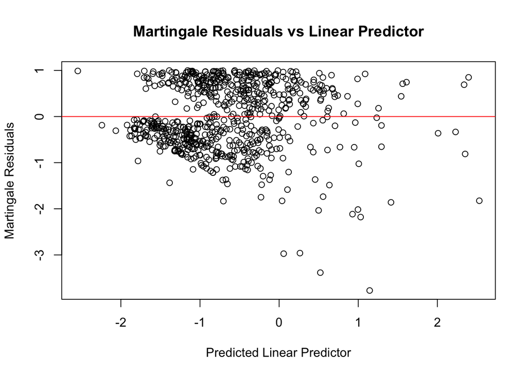

```r
#Martingale Residuals
res_mart= residuals(final_inter_mod, type = "martingale")
vars =  c("age_at_diagnosis",
          "lymph_nodes_examined_positive",
          "nottingham_prognostic_index", "tumor_size")
pred_lp = predict(final_inter_mod, type = "lp")

 plot(
  pred_lp, res_mart,
  xlab = "Predicted Linear Predictor",
  ylab = "Martingale Residuals",
  main = "Martingale Residuals vs Linear Predictor"
)
abline(h = 0, col = "red")
```

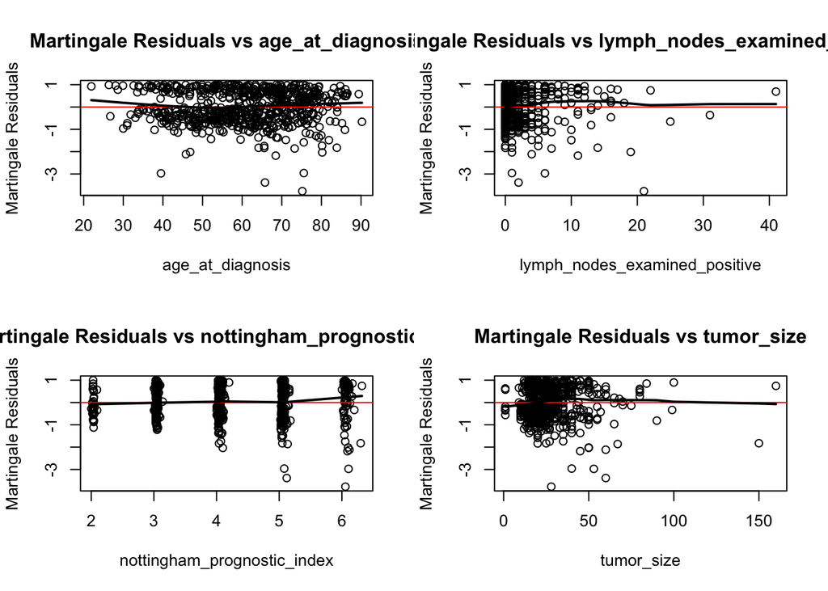

```r
par(mfrow = c(2,2))

for (v in vars) {
  plot(
    data1[[v]], res_mart,
    xlab = v,
    ylab = "Martingale Residuals",
    main = paste("Martingale Residuals vs", v)
  )
  abline(h = 0, col = "red")
  lines(lowess(data1[[v]], res_mart), lwd = 2)
}
```

The Martingale residuals vs. predicted values appear to violate the linearity assumption. The individual plots show there is information which is not caotured by the model which needs to be addressed. Example: The larger notingham prognostic index the larger the residuals.

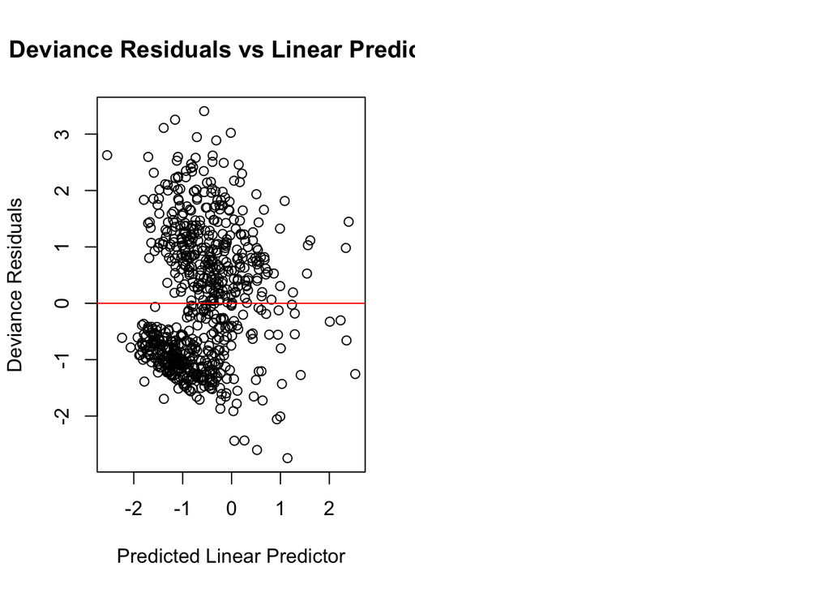

```r
#Deviance residuals

res_dev= residuals(final_inter_mod, type = "deviance")
par(mfrow = c(1,2))

plot(
  pred_lp, res_dev,
  xlab = "Predicted Linear Predictor",
  ylab = "Deviance Residuals",
  main = "Deviance Residuals vs Linear Predictor"
)
abline(h = 0, col = "red")
par(mfrow = c(1,1))
```

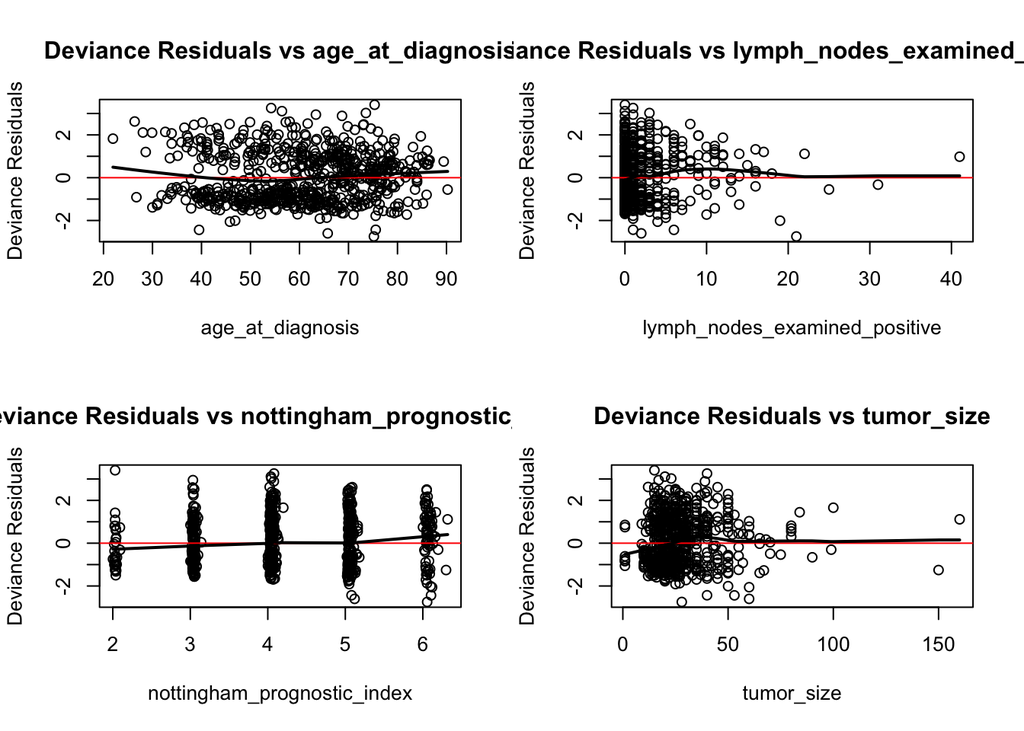

```r
par(mfrow = c(2,2))
for (v in vars) {
  plot(
    data1[[v]], res_dev,
    xlab = v,
    ylab = "Deviance Residuals",
    main = paste("Deviance Residuals vs", v)
  )
  abline(h = 0, col = "red")
  lines(lowess(data1[[v]], res_dev), lwd = 2)
}
```

The deviance residual plots show indication of non-constant covariates as shown in the Martingale residual plots.

```r
# Schoenfeld residuals

cox.zph(final_inter_mod)
```

```
##                                 chisq df       p
## age_at_diagnosis              49.1605  1 2.4e-12
## her2_status                    1.1179  1 0.29038
## hormone_therapy               18.5009  1 1.7e-05
## inferred_menopausal_state     24.9338  1 5.9e-07
## primary_tumor_laterality       0.0469  1 0.82848
## lymph_nodes_examined_positive  0.0418  1 0.83794
## nottingham_prognostic_index    8.4952  1 0.00356
## radio_therapy                  0.6274  1 0.42831
## tumor_size                     0.2723  1 0.60179
## hormone_therapy:tumor_size    14.6934  1 0.00013
## GLOBAL                        71.1562 10 2.7e-11
```

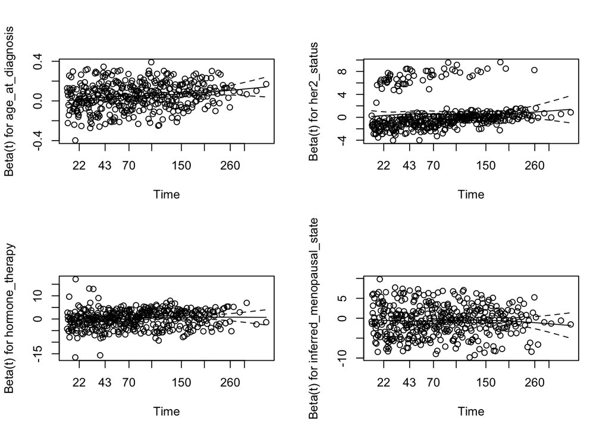

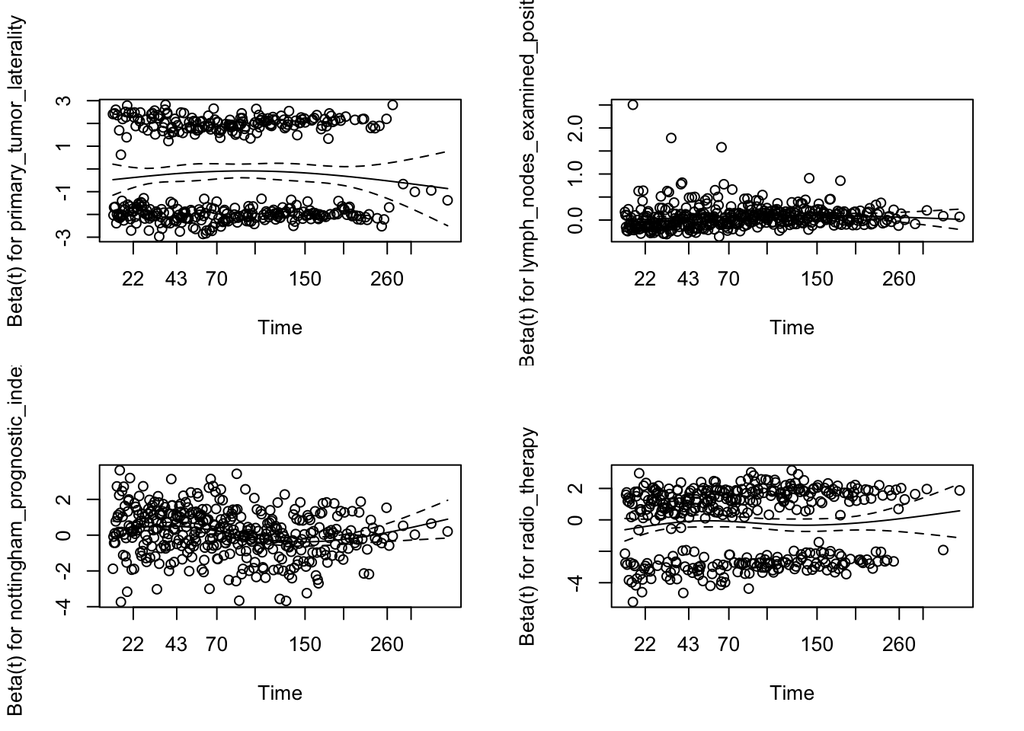

```
## integer(0)
```

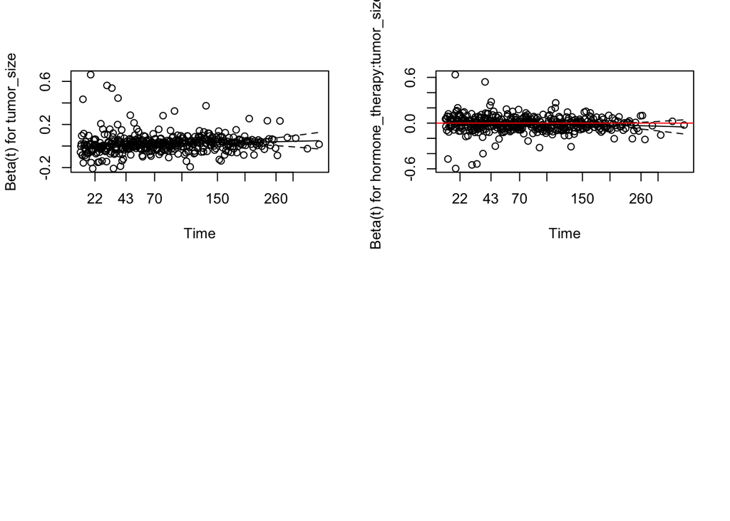

```r
par(mfrow = c(2,2))
plot(cox.zph(final_inter_mod))+
  abline(h = 0, col = "red")
```

The weighted Schoenfeld Residuals show some covariates vary by time which confirms there lacks proportionality across time.

The weighted Schoenfeld Residuals show some covariates vary by time which confirms there lacks proportionality across time.

# Addressing PH assumption Violations

(Do we also want to consider peicewise cox model? or other paramteric survival models using expo~?)

### Stratification

```r
strat_mod = coxph(Surv(overall_survival_months, overall_survival_status ) ~
                        age_at_diagnosis + her2_status + strata(hormone_therapy) +
                        inferred_menopausal_state + primary_tumor_laterality +
                        lymph_nodes_examined_positive + nottingham_prognostic_index +
                        radio_therapy + tumor_size +
                        tumor_size:hormone_therapy + age_at_diagnosis:radio_therapy +
                     age_at_diagnosis:her2_status:lymph_nodes_examined_positive,
                      data=data1)
summary(strat_mod)
```

```
## Call:
## coxph(formula = Surv(overall_survival_months, overall_survival_status) ~
##     age_at_diagnosis + her2_status + strata(hormone_therapy) +
##         inferred_menopausal_state + primary_tumor_laterality +
##         lymph_nodes_examined_positive + nottingham_prognostic_index +
##         radio_therapy + tumor_size + tumor_size:hormone_therapy +
##         age_at_diagnosis:radio_therapy + age_at_diagnosis:her2_status:lymph_nodes_examined_positive,
##     data = data1)
##
##   n= 680, number of events= 387
##
##                                                                          coef
## age_at_diagnosis                                                    0.0547573
## her2_statusPositive                                                 0.5536256
## inferred_menopausal_statePost                                      -0.6524407
## primary_tumor_lateralityRight                                      -0.2305328
## lymph_nodes_examined_positive                                       0.2013518
## nottingham_prognostic_index                                         0.1116386
## radio_therapyYes                                                   -0.2978107
## tumor_size                                                          0.0202563
## tumor_size:hormone_therapyYes                                      -0.0051030
## age_at_diagnosis:radio_therapyYes                                   0.0017655
## age_at_diagnosis:her2_statusNegative:lymph_nodes_examined_positive -0.0019269
## age_at_diagnosis:her2_statusPositive:lymph_nodes_examined_positive -0.0025796
##                                                                     exp(coef)
## age_at_diagnosis                                                    1.0562842
## her2_statusPositive                                                 1.7395485
## inferred_menopausal_statePost                                       0.5207732
## primary_tumor_lateralityRight                                       0.7941104
## lymph_nodes_examined_positive                                       1.2230550
## nottingham_prognostic_index                                         1.1181087
## radio_therapyYes                                                    0.7424419
## tumor_size                                                          1.0204628
## tumor_size:hormone_therapyYes                                       0.9949100
## age_at_diagnosis:radio_therapyYes                                   1.0017671
## age_at_diagnosis:her2_statusNegative:lymph_nodes_examined_positive  0.9980749
## age_at_diagnosis:her2_statusPositive:lymph_nodes_examined_positive  0.9974237
##                                                                      se(coef)
## age_at_diagnosis                                                    0.0083006
## her2_statusPositive                                                 0.1751208
```

[output cut: 81 more lines]

```
## inferred_menopausal_statePost                                         0.7782
## primary_tumor_lateralityRight                                         0.9764
## lymph_nodes_examined_positive                                         1.3617
## nottingham_prognostic_index                                           1.2824
## radio_therapyYes                                                      2.1932
## tumor_size                                                            1.0306
## tumor_size:hormone_therapyYes                                         1.0071
## age_at_diagnosis:radio_therapyYes                                     1.0185
## age_at_diagnosis:her2_statusNegative:lymph_nodes_examined_positive    0.9997
## age_at_diagnosis:her2_statusPositive:lymph_nodes_examined_positive    0.9995
##
## Concordance= 0.695  (se = 0.014 )
## Likelihood ratio test= 192.5  on 12 df,   p=<2e-16
## Wald test            = 218.3  on 12 df,   p=<2e-16
## Score (logrank) test = 235.6  on 12 df,   p=<2e-16
```

### Time varying covariate coefficient

```r
tmv_mod =coxph(
  Surv(overall_survival_months, overall_survival_status) ~  age_at_diagnosis +
    her2_status +  hormone_therapy + inferred_menopausal_state +
    primary_tumor_laterality +   lymph_nodes_examined_positive +  nottingham_prognostic_index +
    radio_therapy + tumor_size +   tumor_size:hormone_therapy + age_at_diagnosis:radio_therapy +
    age_at_diagnosis:her2_status:lymph_nodes_examined_positive +
    tt(age_at_diagnosis) + tt(lymph_nodes_examined_positive) + tt(nottingham_prognostic_index),
  data = data1,
  tt = function(x, t, ...) {
    x * log(t) })

summary(tmv_mod)
```

```
## Call:
## coxph(formula = Surv(overall_survival_months, overall_survival_status) ~
##     age_at_diagnosis + her2_status + hormone_therapy + inferred_menopausal_state +
##         primary_tumor_laterality + lymph_nodes_examined_positive +
##         nottingham_prognostic_index + radio_therapy + tumor_size +
##         tumor_size:hormone_therapy + age_at_diagnosis:radio_therapy +
##         age_at_diagnosis:her2_status:lymph_nodes_examined_positive +
##         tt(age_at_diagnosis) + tt(lymph_nodes_examined_positive) +
##         tt(nottingham_prognostic_index), data = data1, tt = function(x,
##     t, ...) {
##     x * log(t)
## })
##
##   n= 680, number of events= 387
##
##                                                                         coef
## age_at_diagnosis                                                   -0.044529
## her2_statusPositive                                                 0.499043
## hormone_therapyYes                                                  0.013281
## inferred_menopausal_statePost                                      -0.665638
## primary_tumor_lateralityRight                                      -0.231400
## lymph_nodes_examined_positive                                       0.066177
## nottingham_prognostic_index                                         0.732216
## radio_therapyYes                                                   -0.401396
## tumor_size                                                          0.023107
## tt(age_at_diagnosis)                                                0.024029
## tt(lymph_nodes_examined_positive)                                   0.035589
## tt(nottingham_prognostic_index)                                    -0.147275
## hormone_therapyYes:tumor_size                                      -0.009918
## age_at_diagnosis:radio_therapyYes                                   0.002659
## age_at_diagnosis:her2_statusNegative:lymph_nodes_examined_positive -0.002050
## age_at_diagnosis:her2_statusPositive:lymph_nodes_examined_positive -0.002406
##                                                                    exp(coef)
## age_at_diagnosis                                                    0.956448
## her2_statusPositive                                                 1.647145
## hormone_therapyYes                                                  1.013369
## inferred_menopausal_statePost                                       0.513945
## primary_tumor_lateralityRight                                       0.793422
## lymph_nodes_examined_positive                                       1.068416
## nottingham_prognostic_index                                         2.079684
```

[output cut: 121 more lines]

```
## nottingham_prognostic_index                                           3.8931
## radio_therapyYes                                                      1.9872
## tumor_size                                                            1.0335
## tt(age_at_diagnosis)                                                  1.0344
## tt(lymph_nodes_examined_positive)                                     1.0735
## tt(nottingham_prognostic_index)                                       0.9962
## hormone_therapyYes:tumor_size                                         1.0023
## age_at_diagnosis:radio_therapyYes                                     1.0195
## age_at_diagnosis:her2_statusNegative:lymph_nodes_examined_positive    0.9999
## age_at_diagnosis:her2_statusPositive:lymph_nodes_examined_positive    1.0000
##
## Concordance= 0.711  (se = 0.015 )
## Likelihood ratio test= 230.8  on 16 df,   p=<2e-16
## Wald test            = 250.4  on 16 df,   p=<2e-16
## Score (logrank) test = 277.4  on 16 df,   p=<2e-16
```

```r
AIC(final_inter_mod)
```

```
## [1] 4371.367
```

```r
AIC(tmv_mod)
```

```
## [1] 4343.259
```

The time varying coefficient model did lower AIC suggesting slight improvement in the model.

#### Re-check residuals

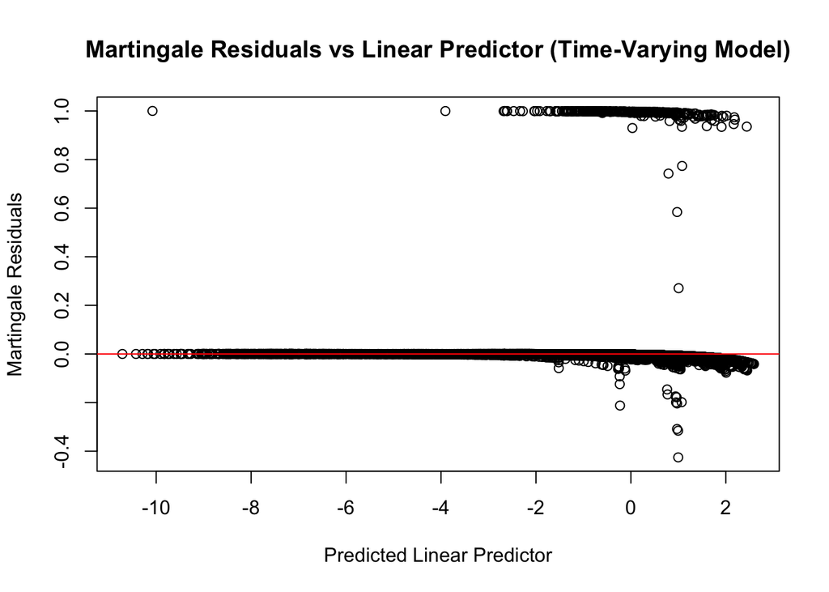

```r
 #  Martingale Residuals
res_mart= residuals(tmv_mod, type = "martingale")

vars = c("age_at_diagnosis",
          "lymph_nodes_examined_positive",
          "nottingham_prognostic_index",
          "tumor_size")

pred_lp=  predict(tmv_mod, type = "lp")

# Residuals vs LP
plot( pred_lp, res_mart,
  xlab = "Predicted Linear Predictor",
  ylab = "Martingale Residuals",
  main = "Martingale Residuals vs Linear Predictor (Time-Varying Model)")
abline(h = 0, col = "red")
```

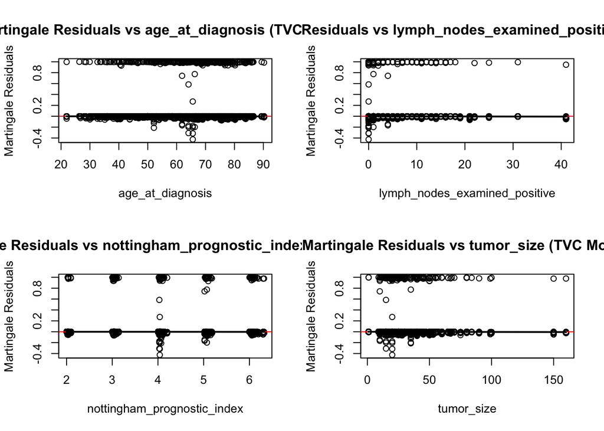

```r
# Residuals vs Covariates
par(mfrow = c(2,2))
for (v in vars) {
  plot(
    model.frame(tmv_mod)[[v]], res_mart,
    xlab = v,
    ylab = "Martingale Residuals",
    main = paste("Martingale Residuals vs", v, "(TVC Model)")
  )
  abline(h = 0, col = "red")
  lines(lowess( model.frame(tmv_mod)[[v]], res_mart), lwd = 2)
}
```

```r
par(mfrow = c(1,1))
```

The individual plots for predictors show all surrounding zero. The nottingham_prognostic_index may be tested with a spline to check if there is sig. non-linearity left. There are some very large tumor sizes while others are smaller, so we may want to redo process with log_tumor_size instead. Other than that there are no significant non-linear trends that we need to account for.

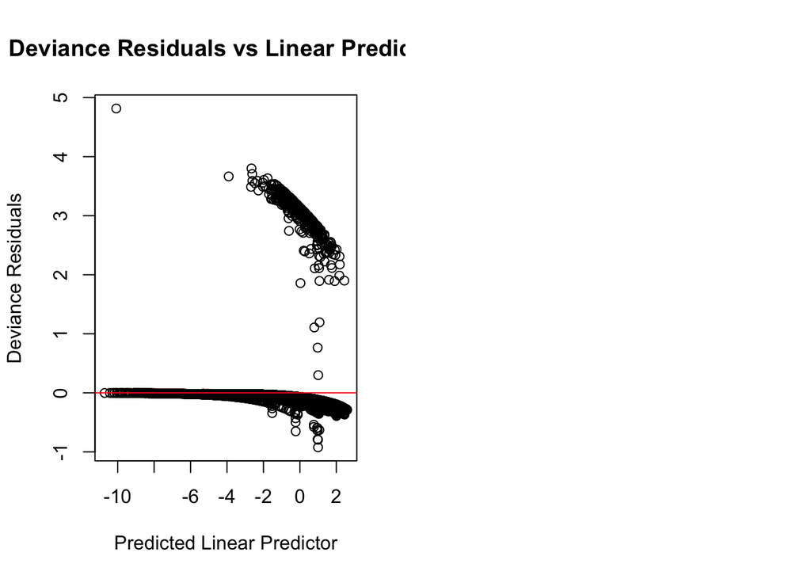

```r
#Deviance residuals
res_dev= residuals(tmv_mod, type = "deviance")
par(mfrow = c(1,2))


plot( pred_lp, res_dev,
  xlab = "Predicted Linear Predictor",
  ylab = "Deviance Residuals",
  main = "Deviance Residuals vs Linear Predictor" )
abline(h = 0, col = "red")
par(mfrow = c(1,1))
```

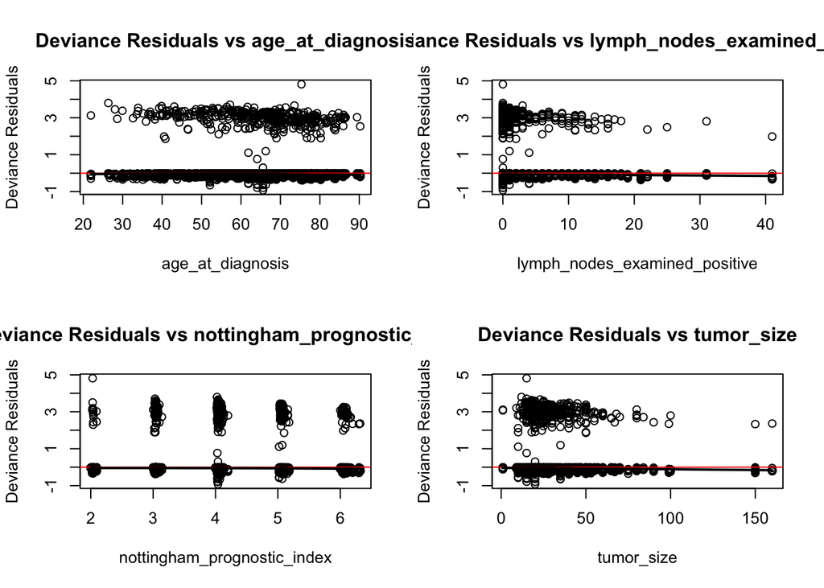

```r
par(mfrow = c(2,2))
for (v in vars) {
  plot(
    model.frame(tmv_mod)[[v]], res_dev,
    xlab = v,
    ylab = "Deviance Residuals",
    main = paste("Deviance Residuals vs", v)
  )
  abline(h = 0, col = "red")
  lines(lowess(model.frame(tmv_mod)[[v]], res_dev), lwd = 2)
}
```

**Can also consider removing outliers to check if it changes significantly**

**If this doesn’t fix the issues then try AFT model or expo regression or weibull regression model**

```r
aft_weibull= survreg(
  Surv(overall_survival_months, overall_survival_status) ~
    age_at_diagnosis +
    her2_status +
    hormone_therapy +
    inferred_menopausal_state +
    primary_tumor_laterality +
    lymph_nodes_examined_positive +
    nottingham_prognostic_index +
    radio_therapy +
    log(tumor_size) +
    log(tumor_size):hormone_therapy +
    age_at_diagnosis:radio_therapy +
    age_at_diagnosis:her2_status:lymph_nodes_examined_positive,
  data = data,
  dist = "weibull"
)

aft_lognormal= update(aft_weibull, dist = "lognormal")
aft_loglogistic= update(aft_weibull, dist = "loglogistic")

AIC(aft_lognormal)
```

```
## [1] 12656.95
```

```r
AIC(aft_weibull)
```

```
## [1] 12569.25
```

```r
AIC(aft_loglogistic)
```

```
## [1] 12605.33
```

The AFT model with the lowest AIC had a weibul distribution.

## Final Model

```r
aft_ci <- exp(confint(aft_weibull))
aft_tr <- exp(coef(aft_weibull))

aft_table <- data.frame(
  Variable = names(aft_tr),
  Time_Ratio = aft_tr,
  CI_Lower = aft_ci[,1],
  CI_Upper = aft_ci[,2]
)

aft_table|>
  knitr::kable()
```

|  | Variable | Time_Ratio | CI_Lower | CI_Upper |
| --- | --- | --- | --- | --- |
| (Intercept) | (Intercept) | 4959.2843688 | 2736.9994322 | 8985.9358978 |
| age_at_diagnosis | age_at_diagnosis | 0.9657321 | 0.9591836 | 0.9723254 |
| her2_statusPositive | her2_statusPositive | 0.7518634 | 0.6473616 | 0.8732347 |
| hormone_therapyYes | hormone_therapyYes | 1.0535489 | 0.5832631 | 1.9030266 |
| inferred_menopausal_statePost | inferred_menopausal_statePost | 1.4429227 | 1.2113401 | 1.7187790 |
| primary_tumor_lateralityRight | primary_tumor_lateralityRight | 1.0627568 | 0.9743718 | 1.1591592 |
| lymph_nodes_examined_positive | lymph_nodes_examined_positive | 0.9083219 | 0.8615608 | 0.9576210 |
| nottingham_prognostic_index | nottingham_prognostic_index | 0.8707219 | 0.8290214 | 0.9145201 |
| radio_therapyYes | radio_therapyYes | 1.5042171 | 0.9306257 | 2.4313418 |
| log(tumor_size) | log(tumor_size) | 0.7556168 | 0.6569963 | 0.8690410 |
| hormone_therapyYes:log(tumor_size) | hormone_therapyYes:log(tumor_size) | 1.0227811 | 0.8519893 | 1.2278104 |
| age_at_diagnosis:radio_therapyYes | age_at_diagnosis:radio_therapyYes | 0.9957048 | 0.9884949 | 1.0029673 |
| age_at_diagnosis:her2_statusNegative:lymph_nodes_examined_positive | age_at_diagnosis:her2_statusNegative:lymph_nodes_examined_positive | 1.0010654 | 1.0002410 | 1.0018905 |
| age_at_diagnosis:her2_statusPositive:lymph_nodes_examined_positive | age_at_diagnosis:her2_statusPositive:lymph_nodes_examined_positive | 1.0010528 | 1.0001039 | 1.0020026 |